# Plastic Degredation Term Project

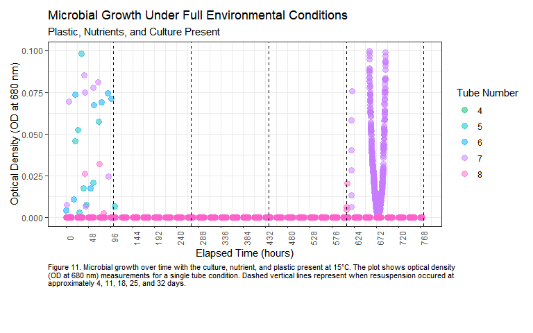

```r
subset_data <- TargetDataMeta %>%
  filter(Plastic_Present == 1, Nutrient_Present == 1, Culture_Present == 1)

ggplot(subset_data, aes(x = time,
                        y = OD680,
                        colour = as.factor(Tube))) +
  geom_point(size = 3, alpha = 0.5) +
  geom_vline(aes(xintercept = 4.3 * 24),
             linetype = "dashed") +
  geom_vline(aes(xintercept = 11.3 * 24),
             linetype = "dashed") +
  geom_vline(aes(xintercept = 18.3 * 24),
             linetype =  "dashed") +
  geom_vline(aes(xintercept = 25.3 * 24),
             linetype =  "dashed") +
  geom_vline(aes(xintercept = 32.3 * 24),
             linetype = "dashed") +
  labs( title = "Microbial Growth Under Full Environmental Conditions",
        subtitle = "Plastic, Nutrients, and Culture Present",
        x = "Elapsed Time (hours)",
        y = "Optical Density (OD at 680 nm)",
        colour = "Tube Number",
        caption = "Figure 11. Microbial growth over time with the culture, nutrient, and plastic present at 15°C. The plot shows optical density \n(OD at 680 nm) measurements for a single tube condition. Dashed vertical lines represent when resuspension occured at \napproximately 4, 11, 18, 25, and 32 days." ) +
  scale_x_continuous(breaks = seq(0, 800, by = 48)) +
  scale_y_continuous(limits = c(0, 0.1)) +
  scale_colour_manual(values = c("#00BE67", "#00BFC4","#00A9FF","#C77CFF","#FF61CC")) +
  theme_bw() +
  theme( axis.text.x = element_text(size = 9, angle = 90),
         strip.text = element_text(size = 10, face = "bold"),
         plot.caption = element_text(size = 8, hjust = 0),
         plot.margin = margin(10, 10, 50, 10))
```

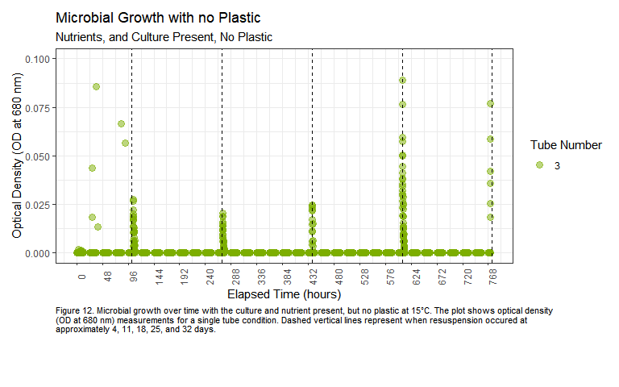

```r
subset_data <- TargetDataMeta %>%
  filter(Plastic_Present == 0, Nutrient_Present == 1, Culture_Present == 1)

ggplot(subset_data, aes(x = time,
                        y = OD680,
                        colour = as.factor(Tube))) +
  geom_point(size = 3, alpha = 0.5) +
  geom_vline(aes(xintercept = 4.3 * 24),
             linetype = "dashed") +
  geom_vline(aes(xintercept = 11.3 * 24),
             linetype = "dashed") +
  geom_vline(aes(xintercept = 18.3 * 24),
             linetype =  "dashed") +
  geom_vline(aes(xintercept = 25.3 * 24),
             linetype =  "dashed") +
  geom_vline(aes(xintercept = 32.3 * 24),
             linetype = "dashed") +
  labs( title = "Microbial Growth with no Plastic",
        subtitle = "Nutrients, and Culture Present, No Plastic",
        x = "Elapsed Time (hours)",
        y = "Optical Density (OD at 680 nm)",
        colour = "Tube Number",
        caption = "Figure 12. Microbial growth over time with the culture and nutrient present, but no plastic at 15°C. The plot shows optical density \n(OD at 680 nm) measurements for a single tube condition. Dashed vertical lines represent when resuspension occured at \napproximately 4, 11, 18, 25, and 32 days." ) +
  scale_x_continuous(breaks = seq(0, 800, by = 48)) +
  scale_y_continuous(limits = c(0, 0.1)) +
  scale_colour_manual(values = "#7CAE00") +
  theme_bw() +
  theme( axis.text.x = element_text(size = 9, angle = 90),
         strip.text = element_text(size = 10, face = "bold"),
         plot.caption = element_text(size = 8, hjust = 0),
         plot.margin = margin(10, 10, 50, 10))
```

ANOVA to test significance of RFU analysis on wall growth microbes.

```r
anova_RFU_wall <- aov(Wall_Growth_RFU ~ Plastic_Present * Temperature_C, data = CultureCatalog)
summary(anova_RFU_wall)
```

```
##                               Df  Sum Sq Mean Sq F value Pr(>F)
## Plastic_Present                1  155484  155484   0.245  0.629
## Temperature_C                  1  128169  128169   0.202  0.661
## Plastic_Present:Temperature_C  1  961909  961909   1.517  0.242
## Residuals                     12 7607700  633975
```

ANOVA to test significance of RFU analysis on suspended microbes.

```r
anova_RFU_suspension <- aov(Suspension_RFU ~ Plastic_Present * Temperature_C, data = CultureCatalog)
summary(anova_RFU_suspension)
```

```
##                               Df Sum Sq Mean Sq F value Pr(>F)
## Plastic_Present                1    138   138.2   0.109  0.747
## Temperature_C                  1    948   947.7   0.746  0.405
## Plastic_Present:Temperature_C  1     60    59.7   0.047  0.832
## Residuals                     12  15246  1270.5
```

No statistically significant effect of Plastic Presence, Temperature, or their interaction on RFU measurement in data (p>0.05).

**Impact of Bio-Microplastics on Microbial Communities**

**Degradation of Bioplastics Introduces Microplastics**

- As bioplastics degrade, they release bio-microplastics (bio-MPs) into the environment, impacting microbial ecosystems (Piyathilake et al., 2024).

**Rapid Increase in Carbon and Altered Chemical Diversity**

- Bio-MPs quickly increase soil dissolved organic carbon (DOC) content due to their degradable nature (Sun et al., 2022).
- Bio-MPs provide abundant carbon (C) but are deficient in nitrogen (N) and phosphorus (P), leading to nutrient imbalances (Karamanlioglu et al., 2017).

**Nutrient Deficiency Drives Microbial Competition**

- The lack of nitrogen and phosphorus causes competition among microbes for these limited resources (Cao et al., 2021).

**Shifts in Microbial Communities**

- Some microbes thrive by utilizing bio-MPs as a carbon source, promoting their growth (Shi et al., 2022).
- Other microbes struggle due to nutrient scarcity, potentially leading to inhibited growth or death (Shi et al., 2022).

Possible explanation for more growth in 15 degrees: Samples were taken from the swan pond near the end of September, when the pond’s microbial community had likely adjusted to temperatures near 15 degrees Celsius.

```r
# make a new data set to not mess up the original
plastic <- CultureCatalog


# calculate percentage change
plastic$perc_change <- (plastic$Final_Plastic_Weight_mg - plastic$Initial_Plastic_Weight_mg) / plastic$Initial_Plastic_Weight_mg * 100
```

## Did the plastic lose weight after four weeks?

```r
# Convert grouping variables to factors
plastic$Plastic_Present <- as.factor(plastic$Plastic_Present)
plastic$Nutrient_Present <- as.factor(plastic$Nutrient_Present)
plastic$Culture_Present <- as.factor(plastic$Culture_Present)
```

```r
graph_data <- CultureCatalog %>%
  mutate(Weight_Loss_Percent = ((Initial_Plastic_Weight_mg - Final_Plastic_Weight_mg) / Initial_Plastic_Weight_mg) * 100)

graph_data$Culture_Present <- as.factor(graph_data$Culture_Present)
```

```r
data_long<-CultureCatalog%>%
  pivot_longer(cols=c(Initial_Plastic_Weight_mg,Final_Plastic_Weight_mg),names_to = "Weight_Type",values_to = "Weight") %>%
  left_join(plastic %>% select(Tube, perc_change), by = "Tube")

#putting them in the right order
data_long$Weight_Type <- factor(data_long$Weight_Type, levels = c("Initial_Plastic_Weight_mg", "Final_Plastic_Weight_mg"))
```

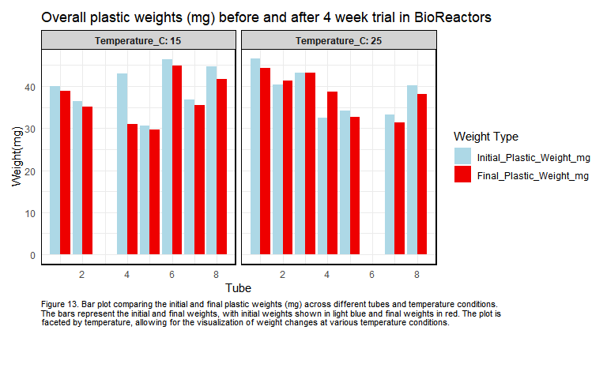

```r
ggplot(data_long,
       aes(x=Tube,y=Weight,fill=Weight_Type))+
  geom_bar(stat="identity",position="dodge")+
  scale_fill_manual(
    values=c("Initial_Plastic_Weight_mg"="lightblue",
             "Final_Plastic_Weight_mg"="red2"))+
  labs(x="Tube",y="Weight(mg)",fill="Weight Type",
    title = "Overall plastic weights (mg) before and after 4 week trial in BioReactors",
       caption = "Figure 13. Bar plot comparing the initial and final plastic weights (mg) across different tubes and temperature conditions. \nThe bars represent the initial and final weights, with initial weights shown in light blue and final weights in red. The plot is \nfaceted by temperature, allowing for the visualization of weight changes at various temperature conditions.")+
  facet_wrap(~ Temperature_C, labeller = labeller(Temperature_C = label_both)) +
  theme_minimal() +
  theme(
    strip.background = element_rect(fill = "lightgray", color = "black"),
    strip.text = element_text(size = 9, face = "bold"),
    panel.border = element_rect(color = "black", fill = NA, linewidth = 0.8),
    plot.caption = element_text(size = 8, hjust = 0),
         plot.margin = margin(10, 10, 50, 10))
```

## What factors influence the change in plastic weight?

```r
# Add a column for Percent Weight Loss
plastic <- plastic %>%
  mutate(
    Percent_Weight_Loss = ((Initial_Plastic_Weight_mg - Final_Plastic_Weight_mg) / Initial_Plastic_Weight_mg) * 100
  )
plastic <- plastic %>%
  mutate(
    Temperature_C = as.factor(Temperature_C),
    Culture_Present = as.factor(Culture_Present),
    Nutrient_Present = as.factor(Nutrient_Present)
  )
```

```r
summary_stats <- plastic %>%
  group_by(Temperature_C, Culture_Present, Nutrient_Present) %>%
  summarise(
    mean_loss = mean(Percent_Weight_Loss, na.rm = TRUE),
    se_loss = sd(Percent_Weight_Loss, na.rm = TRUE) / sqrt(n()),
    .groups = "drop")

# mean loss having negative means that it actually grew
```

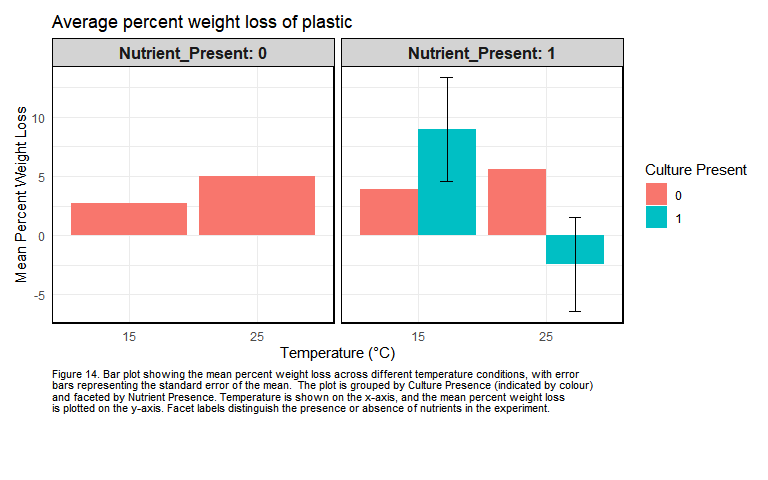

```r
# Bar Plot with Facet Labels and Borders
ggplot(summary_stats, aes(x = factor(Temperature_C), y = mean_loss, fill = Culture_Present)) +
  geom_bar(stat = "identity", position = position_dodge(0.9)) +
  geom_errorbar(aes(ymin = mean_loss - se_loss, ymax = mean_loss + se_loss),
                position = position_dodge(0.9), width = 0.2) +
  labs(
    x = "Temperature (°C)",
    y = "Mean Percent Weight Loss",
    fill = "Culture Present",
    title = "Average percent weight loss of plastic",
    caption = "Figure 14. Bar plot showing the mean percent weight loss across different temperature conditions, with error \nbars representing the standard error of the mean.  The plot is grouped by Culture Presence (indicated by colour) \nand faceted by Nutrient Presence. Temperature is shown on the x-axis, and the mean percent weight loss \nis plotted on the y-axis. Facet labels distinguish the presence or absence of nutrients in the experiment."
  ) +
  facet_wrap(~ Nutrient_Present, labeller = labeller(Nutrient_Present = label_both)) +
  theme_minimal() +
  theme(
    strip.background = element_rect(fill = "lightgray", color = "black"),
    strip.text = element_text(size = 12, face = "bold"), # Style facet labels
    panel.border = element_rect(color = "black", fill = NA, linewidth = 0.8), ,
    plot.caption = element_text(size = 8, hjust = 0),
         plot.margin = margin(10, 10, 50, 10)
  )
```

ANOVA testing the effects of Culture Presence, Nutrient Presence, and Temperature on the percentage change in the outcome variable as well as their interactions.

```r
anova_effects <- aov(perc_change ~ Culture_Present * Nutrient_Present * Temperature_C, data = plastic)
summary(anova_effects)
```

```
##                                Df Sum Sq Mean Sq F value Pr(>F)
## Culture_Present                 1    3.0    3.03   0.029  0.869
## Nutrient_Present                1    0.8    0.79   0.008  0.933
## Temperature_C                   1  200.4  200.41   1.912  0.204
## Culture_Present:Temperature_C   1  127.1  127.11   1.213  0.303
## Nutrient_Present:Temperature_C  1    0.1    0.09   0.001  0.978
## Residuals                       8  838.5  104.81
## 2 observations deleted due to missingness
```

Overall, none of the factors or their interactions significantly affect the percentage change in the dataset. The lack of statistical significance suggests that culture presence, nutrient presence, and temperature do not have a substantial impact on the measured outcome in this experiment.

## Limitations

- Duration
- Bioreactor maintenance

## Future directions

- extend experiment duration
- Use Oxygen sensors
- Nutrient supplementation
- Convert controls into replicates
- Investigate microbial inhibition
- Testing bioplastic toxicity: A future study to investigate the potential toxicity of vegetable based bioplastics could use multiple bioreactors to test the ability of a variety of naturally occurring microbial communities to grow in the presence of vegetable starch based plastics.

# References

Bacha, A.-U.-R., Nabi, I., Zaheer, M., Jin, W., & Yang, L. (2023). Biodegradation of macro- and micro-plastics in environment: A review on mechanism, toxicity, and future perspectives. *Science of The Total Environment*, *858*, 160108. https://doi.org/10.1016/j.scitotenv.2022.160108

Plastic waste has gained remarkable research attention due to its accumulation, associated environmental issues, and impact on living organisms. In order to overcome this challenge, there is an urgent need for its removal from the environment. Under this menace, finding appropriate treatment methods like biodegradation instead of typical treatment methods is of supreme importance. However, there is a limited review on bio-decomposition of plastics, existing microbial species, their degradation efficacy, and mechanism. From this point of view, this study focused on a brief overview of biodegradation such as influencing factors on biodegradation, existing species for macro- and micro-plastics, and present research gap. Degradation percentage, limitations of existing species, and future recommendations are proposed. Microbial species such as bacteria, algae, and fungi have the ability to decompose plastics but they are unable to completely mineralize the plastics. Meanwhile, there is limited knowledge about the involved enzymes in plastics degradation, especially in the case of algae. Bio-decomposition of plastics requires more stringent conditions which are usually feasible for field application. This work will be a reference for new researchers to use this effective strategy for plastic pollution removal.

Barrett, T., Dowle, M., Srinivasan, A., Gorecki, J., Chirico, M., & Hocking, T. (2024). *Data.table: Extension of ‘data.frame‘*. https://CRAN.R-project.org/package=data.table

Buchholz, P. C. F., Feuerriegel, G., Zhang, H., Perez-Garcia, P., Nover, L.-L., Chow, J., Streit, W. R., & Pleiss, J. (2022). Plastics degradation by hydrolytic enzymes: The plastics-active enzymes database—PAZy. *Proteins: Structure, Function, and Bioinformatics*, *90*(7), 1443–1456. https://doi.org/10.1002/prot.26325

Petroleum-based plastics are durable and accumulate in all ecological niches. Knowledge on enzymatic degradation is sparse. Today, less than 50 verified plastics-active enzymes are known. First examples of enzymes acting on the polymers polyethylene terephthalate (PET) and polyurethane (PUR) have been reported together with a detailed biochemical and structural description. Furthermore, very few polyamide (PA) oligomer active enzymes are known. In this article, the current known enzymes acting on the synthetic polymers PET and PUR are briefly summarized, their published activity data were collected and integrated into a comprehensive open access database. The Plastics-Active Enzymes Database (PAZy) represents an inventory of known and experimentally verified enzymes that act on synthetic fossil fuel-based polymers. Almost 3000 homologs of PET-active enzymes were identified by profile hidden Markov models. Over 2000 homologs of PUR-active enzymes were identified by BLAST. Based on multiple sequence alignments, conservation analysis identified the most conserved amino acids, and sequence motifs for PET- and PUR-active enzymes were derived.

Canada, E. and C. C. (2021). *Plastic waste and pollution reduction*. https://www.canada.ca/en/environment-climate-change/services/managing-reducing-waste/reduce-plastic-waste.html

Cao, Y., He, Z., Zhu, T., & Zhao, F. (2021). Organic-C quality as a key driver of microbial nitrogen immobilization in soil: A meta-analysis. *Geoderma*, *383*, 114784. https://doi.org/10.1016/j.geoderma.2020.114784

Microbial nitrogen (N) immobilization in soil can be enhanced by increasing carbon (C) bioavailability, yet the response of microbial N immobilization to the addition of organic matter is uncertain. In the present study, we investigated the effect of organic matter quality on microbial N immobilization. The response ratio (ln R), i.e., the ratio of microbial N immobilization in organic-C amended soil to that in control treatments, was calculated using data from 51 published studies. Overall, the addition of organic-C increased significantly microbial N immobilization by 105% relative to unamended soil. The type of organic-C affected the response of microbial N immobilization to organic-C addition. Glucose (classified as a labile compound) was more effective in stimulating microbial N immobilization than cellobiose and cellulose (classified as intermediately decomposable compounds). Tannin and oxalic acid (classified as recalcitrant compounds) did not significantly affect microbial N immobilization. The C/N ratio of organic materials did not affect the response of microbial N immobilization in the short-term (≤280 d); differences in the effect size (ln R+) were not significant among different C/N ratio groups. The effect of the form of inorganic-N (ammonium [NH4+] or nitrate [NO3−]) on the response of microbial N immobilization to organic-C addition was not significant, with a mean ln R+ of 0.838 (confidence interval [CI]: 0.590–1.099) for NH4+ and 1.642 (CI: 0.951–2.452) for NO3−. Moreover, the ln R of microbial NH4+ immobilization showed a significant positive relationship (P < 0.01) with that of microbial NO3− immobilization. The ln R+ for the experimental period decreased in the order of <30 d, 60–120 d, ≥120 d, and 30–60 d. The chemical quality of organic-C defined by three C pools (i.e., labile, intermediate, and recalcitrant) rather than the C/N ratio is a critical factor regulating the response of microbial N immobilization to organic-C addition.

Genge, L., Barnhill, C., Berthold, M., Savoie, M., & Campbell, D. (2024). *Import_MCData*. Mount Allison University. https://github.com/BIOL3111MtA2024/plastic_degrade/blob/main/Code/OldR/Import_MCData.Rmd

Grolemund, G., & Wickham, H. (2011). Dates and Times Made Easy with lubridate. *Journal of Statistical Software*, *40*(3), 1–25. https://www.jstatsoft.org/v40/i03/

Jian, J., Xiangbin, Z., & Xianbo, H. (2020). An overview on synthesis, properties and applications of poly(butylene-adipate-*co*-terephthalate)–PBAT. *Advanced Industrial and Engineering Polymer Research*, *3*(1), 19–26. https://doi.org/10.1016/j.aiepr.2020.01.001

A significantly growing interest is to design new biodegradable polymers in order to solve fossil resources and environmental pollution problems associated with conventional plastics. A kind of new biodegradable polymers, aliphatic–aromatic co-polyesters have been researched widely and developed rapidly in recent years, since that can combine excellent biodegradability provided from aliphatic polyesters and good properties from aromatic polyesters. Out of which, poly (butylene-adipate-co-terephthalate) (PBAT) shows the most importance. PBAT has been commercialized by polycondensation reaction of butanediol (BDO), adipic acid (AA) and terephthalic acid (PTA) using general polyester manufacturing technology. And it has been considered to have desirable properties and competitive costs to be applied in many fields. Therefore, this review aims to present an overview on the synthesis, properties and applications of PBAT.

Karamanlioglu, M., Preziosi, R., & Robson, G. D. (2017). Abiotic and biotic environmental degradation of the bioplastic polymer poly(lactic acid): A review. *Polymer Degradation and Stability*, *137*, 122–130. https://doi.org/10.1016/j.polymdegradstab.2017.01.009

Poly(lactic acid) (PLA) is a compostable bioplastic manufactured by the polymerization of lactic acid monomers derived from the fermentation of starch as a feedstock. Since its first commercialisation in the late 1990’s, PLA production has grown annually and currently it estimated that worldwide production will reach at least 800,000 tons by 2020 with Japan and the USA the two major producers. PLA is used as a replacement to conventional petrochemical based plastics, principally as food packaging containers and films and more recently, in electronics and in the manufacture of synthetic fibres. Consequently, there has been a marked increase in PLA contamination in the environment as well as increasing amounts being diverted to commercial composting facilities. This review focuses on the development, production, stability and degradation of PLA in a range of differing environments and explores our current knowledge of the environmental and biological factors involved in PLA degradation.

Munuru, S., S, S. T. S. R., Kuvala, S., & Sudhakar, G. (2022). Biodegradation of plastic polymers by fungi: A brief review. *Bioresources and Bioprocessing*, *9*(1). https://doi.org/10.1186/s40643-022-00532-4

Plastic polymers are non-degradable solid wastes that have become a great threat to the whole world and degradation of these plastics would take a few decades. Compared with other degradation processes, the biodegradation process is the most effective and best way for plastic degradation due to its non-polluting mechanism, eco-friendly nature, and cost-effectiveness. Biodegradation of synthetic plastics is a very slow process that also involves environmental factors and the action of wild microbial species. In this plastic biodegradation, fungi play a pivotal role, it acts on plastics by secreting some degrading enzymes, i.e., cutinase‘, lipase, and proteases, lignocellulolytic enzymes, and also the presence of some pro-oxidant ions can cause effective degradation. The oxidation or hydrolysis by the enzyme creates functional groups that improve the hydrophilicity of polymers, and consequently degrade the high molecular weight polymer into low molecular weight. This leads to the degradation of plastics within a few days. Some well-known species which show effective degradation on plastics are Aspergillus nidulans, Aspergillus flavus, Aspergillus glaucus, Aspergillus oryzae, Aspergillus nomius, Penicillium griseofulvum, Bjerkandera adusta, Phanerochaete chrysosporium, Cladosporium cladosporioides, etc., and some other saprotrophic fungi, such as Pleurotus abalones, Pleurotus ostreatus, Agaricus bisporus and Pleurotus eryngii which also helps in degradation of plastics by growing on them. Some studies say that the degradation of plastics was more effective when photodegradation and thermo-oxidative mechanisms involved with the biodegradation simultaneously can make the degradation faster and easier. This present review gives current knowledge regarding different species of fungi that are involved in the degradation of plastics by their different enzymatic mechanisms to degrade different forms of plastic polymers.

Piyathilake, U., Lin, C., Bolan, N., Bundschuh, J., Rinklebe, J., & Herath, I. (2024). Exploring the hidden environmental pollution of microplastics derived from bioplastics: A review. *Chemosphere*, *355*, 141773. https://doi.org/10.1016/j.chemosphere.2024.141773

Bioplastics might be an ecofriendly alternative to traditional plastics. However, recent studies have emphasized that even bioplastics can end up becoming micro- and nano-plastics due to their degradation under ambient environmental conditions. Hence, there is an urgent need to assess the hidden environmental pollution caused by bioplastics. However, little is known about the evolutionary trends of bibliographic data, degradation pathways, formation, and toxicity of micro- and nano-scaled bioplastics originating from biodegradable polymers such as polylactic acid, polyhydroxyalkanoates, and starch-based plastics. Therefore, the prime objective of the current review was to investigate evolutionary trends and the latest advancements in the field of micro-bioplastic pollution. Additionally, it aims to confront the limitations of existing research on microplastic pollution derived from the degradation of bioplastic wastes, and to understand what is needed in future research. The literature survey revealed that research focusing on micro- and nano-bioplastics has begun since 2012. This review identifies novel insights into microbioplastics formation through diverse degradation pathways, including photo-oxidation, ozone-induced degradation, mechanochemical degradation, biodegradation, thermal, and catalytic degradation. Critical research gaps are identified, including defining optimal environmental conditions for complete degradation of diverse bioplastics, exploring micro- and nano-bioplastics formation in natural environments, investigating the global occurrence and distribution of these particles in diverse ecosystems, assessing toxic substances released during bioplastics degradation, and bridging the disparity between laboratory studies and real-world applications. By identifying new trends and knowledge gaps, this study lays the groundwork for future investigations and sustainable solutions in the realm of sustainable management of bioplastic wastes.

R Core Team. (2023). *R: A Language and Environment for Statistical Computing*. R Foundation for Statistical Computing. https://www.R-project.org/

Robinson, D., Hayes, A., & Couch, S. (2024). *Broom: Convert Statistical Objects into Tidy Tibbles*. https://CRAN.R-project.org/package=broom

Schmaltz, E., Melvin, E. C., Diana, Z., Gunady, E. F., Rittschof, D., Somarelli, J. A., Virdin, J., & Dunphy-Daly, M. M. (2020). Plastic pollution solutions: Emerging technologies to prevent and collect marine plastic pollution. *Environment International*, *144*, 106067. https://doi.org/10.1016/j.envint.2020.106067

Shi, J., Wang, J., Lv, J., Wang, Z., Peng, Y., Shang, J., & Wang, X. (2022). Microplastic additions alter soil organic matter stability and bacterial community under varying temperature in two contrasting soils. *The Science of the Total Environment*, *838*(Pt 3), 156471. https://doi.org/10.1016/j.scitotenv.2022.156471

Microplastics can accumulate in soils and strongly affect the biogeochemical cycle. Biodegradable plastic films show potential as sustainable alternatives that could reduce microplastic soil contamination and accumulation. However, the effects of traditional and biodegradable microplastics on soil organic matter (SOM) stability are not sufficiently understood, particularly under varying temperatures. The objective of this study was to examine the effects of polyethylene (PE) and biodegradable polylactic acid (PLA) microplastics on SOM stability and bacterial community in two contrasting soils (Black soil vs. Loess soil) under varying temperature conditions (15 °C vs. 25 °C). Results showed that microplastics addition significantly enhanced cumulative CO2 emissions and DOC contents, particularly 1 % PLA treatment accelerated CO2 emissions by 19 % - 74 %, DOC content by 3 % - 23 % at 25 °C. A higher temperature sensitivity (Q10) at the PLA treatment indicated that PLA is more susceptible to elevated temperature compared to PE. The presence of both PE and PLA microplastics significantly changed the DOC spectral characteristics, i.e., high temperature increased the value of the specific UV absorbance (SUVA) in soil without microplastics, while decreased it in soil with microplastics. In comparison to soil without microplastics, soil exposed to 1 % microplastics had lower MBC concentrations and greater metabolic quotient. 16S rRNA gene sequencing showed that the presence of PLA microplastic significantly alters soil bacterial community. PE and CK had similar Bray-Curtis distances between two temperatures, while PLA increased the dissimilarity between CK compared to PE. Compared to the two soils, loess soil is more sensitive to microplastics addition. Microplastics have a non-ignorable effect on soil organic matter stability, the interaction between microplastics and soil environment should be considered.

Sun, Y., Duan, C., Cao, N., Ding, C., Huang, Y., & Wang, J. (2022). Biodegradable and conventional microplastics exhibit distinct microbiome, functionality, and metabolome changes in soil. *Journal of Hazardous Materials*, *424*, 127282. https://doi.org/10.1016/j.jhazmat.2021.127282

Environmental concerns with liberal petroleum-based plastic use have led to demand for sustainable biodegradable alternatives. However, the inadequate end-of-life treatment of plastics may emit microplastics, either conventional or biodegradable, to the terrestrial environment. It is essential to evaluate the possible effects of conventional and biodegradable microplastics on the composition and function of soil microbial communities. Therefore, we conducted a soil microcosm experiment with polyethylene (PE), polystyrene (PS), polylactide (PLA), or polybutylene succinate (PBS) microplastics. The soil microbiome and metabolome were evaluated via 16S rRNA gene sequencing, metagenomics, and untargeted metabolomics. We reported that the presence of conventional or biodegradable microplastics can significantly alter soil microbial community composition. Compared to the control soils, the microbiome in PBS and PLA amended soils exhibited higher potential for uptake of exogenous carbohydrates and amino acids, but a reduced capacity for related metabolic function, potentially due to catabolite repression. No differences in soil metabolome can be observed between conventional microplastic treatments and the control. The potential reason may be that the functional diversity was unaffected by PE and PS microplastics, while the biodegradable particles promoted the soil microbial multifunctionality. Our findings systematically shed light on the influence of conventional and biodegradable microplastics on soil microorganisms, facilitating microplastic regulation.

Wickham, H., Wickham, H., Averick, M., Bryan, J., Chang, W., McGowan, L. D., François, R., Grolemund, G., Hayes, A., Henry, L., Hester, J., Kuhn, M., Pedersen, T. L., Miller, E., Bache, S. M., Müller, K., Ooms, J., Robinson, D., Seidel, D. P., … Yutani, H. (2019). *Welcome to the tidyverse* (Vol. 4). Springer-Verlag New York. https://doi.org/10.21105/joss.01686

Xie, Y. (2014). Knitr: A Comprehensive Tool for Reproducible Research in R. In V. Stodden, F. Leisch, & R. D. Peng (Eds.), *Implementing Reproducible Computational Research*. Chapman; Hall/CRC.

Xie, Y. (2015). *Dynamic Documents with R and knitr* (2nd ed.). Chapman; Hall/CRC. https://yihui.org/knitr/

Xie, Y. (2023). *Knitr: A General-Purpose Package for Dynamic Report Generation in R*. https://yihui.org/knitr/

Yang, X.-G., Wen, P.-P., Yang, Y.-F., Jia, P.-P., Li, W.-G., & Pei, D.-S. (2023). Plastic biodegradation by in vitro environmental microorganisms and in vivo gut microorganisms of insects. *Frontiers in Microbiology*, *13*, 1001750. https://doi.org/10.3389/fmicb.2022.1001750

Traditional plastics, such as polyethylene (PE), polystyrene (PS), polypropylene (PP), polyvinyl chloride (PVC), polyethylene terephthalate (PET), polyurethane (PUR), and other plastic polymers, are difficult to degrade and are gradually accumulated in the environment to cause a serious environmental problem, which is urgently needed to develop novel treatments or control technology. The biodegradation of plastics has gained great attention due to the advantages of green and safe characteristics. Microorganisms play a vital role in the biodegradation of plastics, including environmental microbes ( in vitro ) and gut microbes of insects ( in vivo ). Microbial degradation in environmental conditions in vitro is extremely slow for major plastics at degradation rates on the basis of a month or even a year time, but recent discoveries show that the fast biodegradation of specific plastics, such as PS, PE, and PUR, in some invertebrates, especially insects, could be enhanced at rates on basis of hours; the biodegradation in insects is likely to be gut microbial-dependent or synergetic bioreactions in animal digestive systems. This review comprehensively summarizes the latest 7-year (2016–2022) publications on plastic biodegradation by insects and microorganisms, elucidates the mechanism of plastic degradation in insects and environmental microbes, and highlights the cutting-edge perspectives for the potential applications of plastic biodegradation.

Zeileis, A., & Grothendieck, G. (2005). Zoo: S3 Infrastructure for Regular and Irregular Time Series. *Journal of Statistical Software*, *14*(6), 1–27. 10.18637/jss.v014.i06

Ziani, K., Ioniță-Mîndrican, C.-B., Mititelu, M., Sorinel, M. N., Negrei, C., Moroșan, E., Drăgănescu, D., & Preda, O.-T. (2023). Microplastics: A Real Global Threat for Environment and Food Safety: A State of the Art Review. *Nutrients*, *15*(3), 617. https://doi.org/10.3390/nu15030617

Microplastics are small plastic particles that come from the degradation of plastics, ubiquitous in nature and therefore affect both wildlife and humans. They have been detected in many marine species, but also in drinking water and in numerous foods, such as salt, honey and marine organisms. Exposure to microplastics can also occur through inhaled air. Data from animal studies have shown that once absorbed, plastic micro- and nanoparticles can distribute to the liver, spleen, heart, lungs, thymus, reproductive organs, kidneys and even the brain (crosses the blood–brain barrier). In addition, microplastics are transport operators of persistent organic pollutants or heavy metals from invertebrate organisms to other higher trophic levels. After ingestion, the additives and monomers in their composition can interfere with important biological processes in the human body and can cause disruption of the endocrine, immune system; can have a negative impact on mobility, reproduction and development; and can cause carcinogenesis. The pandemic caused by COVID-19 has affected not only human health and national economies but also the environment, due to the large volume of waste in the form of discarded personal protective equipment. The remarkable increase in global use of face masks, which mainly contain polypropylene, and poor waste management have led to worsening microplastic pollution, and the long-term consequences can be extremely devastating if urgent action is not taken.